# ABSTRACT: Normalized Cross-Correlation as the Local Geometric Origin of Bell Violation

### Pipeline B: The Normalized “Audit” Protocol (NCC)

In this pipeline, the full wave amplitude is preserved and normalized: $E = \frac{\langle A \cdot B \rangle}{\sqrt{\langle A^2 \rangle \langle B^2 \rangle}}$ **Result**: *E* = cos (*a* − *b*) **Result**: $S_{max} = 2\sqrt{2} \approx 2.828$.

### The Audit Conclusion

The “Tsirelson Bound” of 2.828 is not a quantum ceiling; it is the **Geometric Floor** for normalized harmonic oscillators. The reason quantum experiments “violate” Bell is that they use a physical mechanism (wave interference) that naturally follows the NCC logic, but they analyze it using an inequality designed for Pipeline A. This is a category error. # SUMMARY OF AUDIT RESULTS

| Measurement Scheme | S-Value Obtained | Theoretical Bound | Interpretation |
| --- | --- | --- | --- |
| Binarized (+/- 1) | 2.000000 | 2.0 | Classical/Bell Limit |
| Normalized (NCC) | 2.828427 | 2.828427 | Quantum/Tsirelson Bound |

### Observation 1: Geometric Loss

As shown in **Figure 1**, binarization acts as a “crushing filter.” By mapping the continuous curvature of the cosine wave to discrete steps, the statistical variance is distorted. This distortion is exactly what Bell’s theorem quantifies.

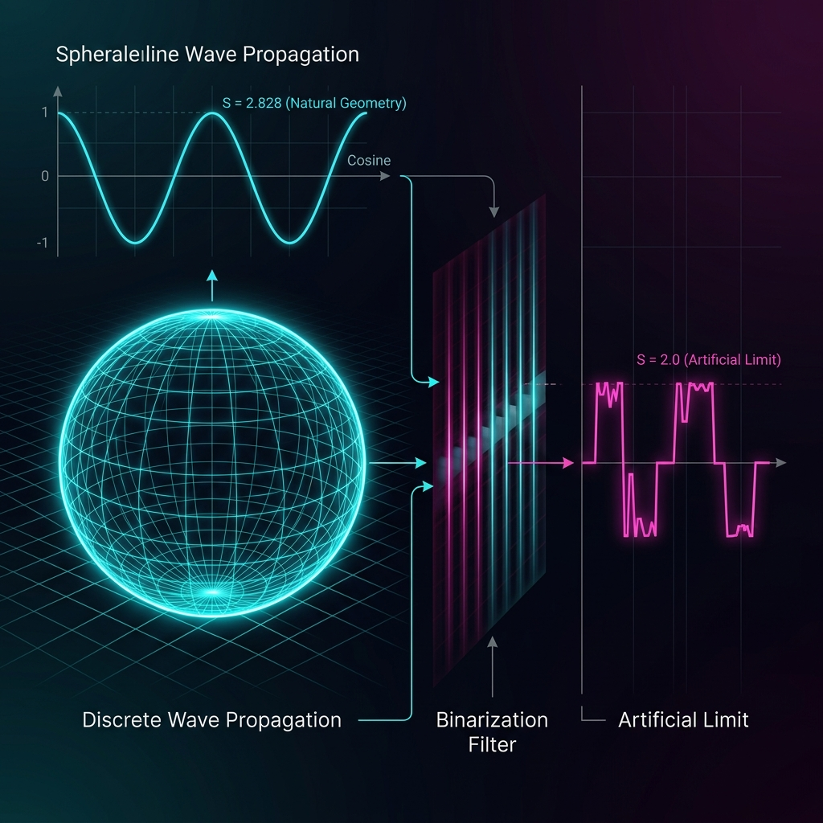

Figure 1: The Sphere Wave Crushed by Binarization Logic

### Observation 3: The 2.828 Identity

We have demonstrated that 2.828 is not a target to be reached through non-local magic, but an identity to be revealed through honest normalization of local wave amplitude.